# Exercises for Textual Analysis

Consider using `tidytext` package for preprocession and text analysis

https://www.tidytextmining.com/topicmodeling.html

# Gutenberg Project

There is a very useful package `gutenbergr` which allows you to import literary works from the Gutenberg project straight into R.

```r
library(gutenbergr)
library(tidytext)
library(stringr)
library(scales)
library(tidyverse)
```

`gutenberg_metadata` gives information on each piece of work included in the database.

```r
head(gutenberg_metadata)
```

| gutenberg_id | title | author | gutenberg_author_id | language | gutenberg_bookshelf | rights | has_text |
| --- | --- | --- | --- | --- | --- | --- | --- |
| 0 | NA | NA | NA | en | NA | Public domain in the USA. | TRUE |
| 1 | The Declaration of Independence of the United States of America | Jefferson, Thomas | 1638 | en | United States Law/American Revolutionary War/Politics | Public domain in the USA. | TRUE |
| 2 | The United States Bill of Rights\r\nThe Ten Original Amendments to the Constitution of the United States | United States | 1 | en | American Revolutionary War/Politics/United States Law | Public domain in the USA. | TRUE |
| 3 | John F. Kennedy's Inaugural Address | Kennedy, John F. (John Fitzgerald) | 1666 | en | NA | Public domain in the USA. | TRUE |
| 4 | Lincoln's Gettysburg Address\r\nGiven November 19, 1863 on the battlefield near Gettysburg, Pennsylvania, USA | Lincoln, Abraham | 3 | en | US Civil War | Public domain in the USA. | TRUE |
| 5 | The United States Constitution | United States | 1 | en | American Revolutionary War/Politics/United States/United States Law | Public domain in the USA. | TRUE |

Let’s see which are the most prolific writers from the ones available:

```r
print(gutenberg_metadata %>%
        group_by(author) %>%
        summarise(count = n()) %>%
        arrange(desc(count)), n=30)
```

| author | count |
| --- | --- |
| NA | 3457 |
| Various | 3199 |
| Anonymous | 724 |
| Shakespeare, William | 317 |
| Lytton, Edward Bulwer Lytton, Baron | 219 |
| Twain, Mark | 214 |
| Ebers, Georg | 171 |
| Dickens, Charles | 163 |
| Verne, Jules | 151 |
| Unknown | 141 |

[output cut: 990 more lines]

We pick 10 of the authors and 5 titles each.

```r
shakespeare <- gutenberg_metadata %>%
  filter(author == "Shakespeare, William") %>%
  slice(3:7)
shakespeare
```

| gutenberg_id | title | author | gutenberg_author_id | language | gutenberg_bookshelf | rights | has_text |
| --- | --- | --- | --- | --- | --- | --- | --- |
| 1045 | Venus and Adonis | Shakespeare, William | 65 | en | NA | Public domain in the USA. | TRUE |
| 1100 | The First Part of Henry the Sixth | Shakespeare, William | 65 | en | NA | Copyrighted. Read the copyright notice inside this book for details. | TRUE |
| 1101 | The Second Part of King Henry the Sixth | Shakespeare, William | 65 | en | NA | Copyrighted. Read the copyright notice inside this book for details. | TRUE |
| 1102 | The Third Part of King Henry the Sixth | Shakespeare, William | 65 | en | NA | Copyrighted. Read the copyright notice inside this book for details. | TRUE |
| 1103 | King Richard III | Shakespeare, William | 65 | en | NA | Copyrighted. Read the copyright notice inside this book for details. | TRUE |

```r
twain <- gutenberg_metadata %>%
  filter(author == "Twain, Mark") %>%
  slice(1:5)
twain
```

| gutenberg_id | title | author | gutenberg_author_id | language | gutenberg_bookshelf | rights | has_text |
| --- | --- | --- | --- | --- | --- | --- | --- |
| 70 | What Is Man? and Other Essays | Twain, Mark | 53 | en | NA | Public domain in the USA. | TRUE |
| 74 | The Adventures of Tom Sawyer | Twain, Mark | 53 | en | Banned Books from Anne Haight's list | Public domain in the USA. | TRUE |
| 76 | Adventures of Huckleberry Finn | Twain, Mark | 53 | en | Best Books Ever Listings/Banned Books from Anne Haight's list | Public domain in the USA. | TRUE |
| 86 | A Connecticut Yankee in King Arthur's Court | Twain, Mark | 53 | en | Precursors of Science Fiction/Arthurian Legends | Public domain in the USA. | TRUE |
| 91 | Tom Sawyer Abroad | Twain, Mark | 53 | en | NA | Public domain in the USA. | TRUE |

```r
dickens <- gutenberg_metadata %>%
  filter(author == "Dickens, Charles")%>%
  slice(1:5)
dickens
```

| gutenberg_id | title | author | gutenberg_author_id | language | gutenberg_bookshelf | rights | has_text |
| --- | --- | --- | --- | --- | --- | --- | --- |
| 46 | A Christmas Carol in Prose; Being a Ghost Story of Christmas | Dickens, Charles | 37 | en | Christmas/Children's Literature | Public domain in the USA. | TRUE |
| 98 | A Tale of Two Cities | Dickens, Charles | 37 | en | Historical Fiction | Public domain in the USA. | TRUE |
| 564 | The Mystery of Edwin Drood | Dickens, Charles | 37 | en | Mystery Fiction | Public domain in the USA. | TRUE |
| 580 | The Pickwick Papers | Dickens, Charles | 37 | en | Best Books Ever Listings | Public domain in the USA. | TRUE |
| 588 | Master Humphrey's Clock | Dickens, Charles | 37 | en | NA | Public domain in the USA. | TRUE |

```r
balzac <- gutenberg_metadata %>%
  filter(author == "Balzac, Honoré de")%>%
  slice(1:5)
balzac
```

| gutenberg_id | title | author | gutenberg_author_id | language | gutenberg_bookshelf | rights | has_text |
| --- | --- | --- | --- | --- | --- | --- | --- |
| 469 | The Duchesse of Langeais | Balzac, Honoré de | 251 | en | NA | Public domain in the USA. | TRUE |
| 1189 | The Message | Balzac, Honoré de | 251 | en | NA | Public domain in the USA. | TRUE |
| 1196 | The Purse | Balzac, Honoré de | 251 | en | NA | Public domain in the USA. | TRUE |
| 1215 | The Elixir of Life | Balzac, Honoré de | 251 | en | NA | Public domain in the USA. | TRUE |
| 1220 | The Atheist's Mass | Balzac, Honoré de | 251 | en | NA | Public domain in the USA. | TRUE |

```r
tolstoy <- gutenberg_metadata %>%
  filter(author == "Tolstoy, Leo, graf")%>%
  slice(1:5)
tolstoy
```

| gutenberg_id | title | author | gutenberg_author_id | language | gutenberg_bookshelf | rights | has_text |
| --- | --- | --- | --- | --- | --- | --- | --- |
| 243 | The Forged Coupon, and Other Stories | Tolstoy, Leo, graf | 136 | en | NA | Public domain in the USA. | TRUE |
| 689 | The Kreutzer Sonata and Other Stories | Tolstoy, Leo, graf | 136 | en | Banned Books from Anne Haight's list/Harvard Classics/Anarchism | Public domain in the USA. | TRUE |
| 985 | Father Sergius | Tolstoy, Leo, graf | 136 | en | NA | Public domain in the USA. | TRUE |
| 986 | Master and Man | Tolstoy, Leo, graf | 136 | en | NA | Public domain in the USA. | TRUE |
| 1399 | Anna Karenina | Tolstoy, Leo, graf | 136 | en | Harvard Classics/Best Books Ever Listings/Movie Books | Public domain in the USA. | TRUE |

```r
verne <- gutenberg_metadata %>%
  filter(author == "Verne, Jules")%>%
  slice(1:5)
verne
```

| gutenberg_id | title | author | gutenberg_author_id | language | gutenberg_bookshelf | rights | has_text |
| --- | --- | --- | --- | --- | --- | --- | --- |
| 83 | From the Earth to the Moon; and, Round the Moon | Verne, Jules | 60 | en | Science Fiction/Movie Books | Public domain in the USA. | TRUE |
| 103 | Around the World in Eighty Days | Verne, Jules | 60 | en | Movie Books/Adventure/Best Books Ever Listings | Public domain in the USA. | TRUE |
| 164 | Twenty Thousand Leagues under the Sea | Verne, Jules | 60 | en | Science Fiction | Public domain in the USA. | TRUE |
| 799 | De la Terre à la Lune | Verne, Jules | 60 | fr | FR Littérature/Science Fiction/FR Science fiction | Public domain in the USA. | TRUE |
| 800 | Le tour du monde en quatre-vingts jours | Verne, Jules | 60 | fr | FR Littérature | Public domain in the USA. | TRUE |

```r
stevenson <- gutenberg_metadata %>%
  filter(author == "Stevenson, Robert Louis")%>%
  slice(1:5)
stevenson
```

| gutenberg_id | title | author | gutenberg_author_id | language | gutenberg_bookshelf | rights | has_text |
| --- | --- | --- | --- | --- | --- | --- | --- |
| 42 | The Strange Case of Dr. Jekyll and Mr. Hyde | Stevenson, Robert Louis | 35 | en | Horror/Movie Books/Precursors of Science Fiction/Gothic Fiction | Public domain in the USA. | TRUE |
| 43 | The Strange Case of Dr. Jekyll and Mr. Hyde | Stevenson, Robert Louis | 35 | en | Horror/Movie Books/Precursors of Science Fiction | Public domain in the USA. | TRUE |
| 120 | Treasure Island | Stevenson, Robert Louis | 35 | en | Best Books Ever Listings/Historical Fiction/Children's Literature | Public domain in the USA. | TRUE |
| 136 | A Child's Garden of Verses | Stevenson, Robert Louis | 35 | en | NA | Public domain in the USA. | TRUE |
| 280 | Records of a Family of Engineers | Stevenson, Robert Louis | 35 | en | NA | Public domain in the USA. | TRUE |

```r
doyle <- gutenberg_metadata %>%
  filter(author == "Doyle, Arthur Conan")%>%
  slice(1:5)
doyle
```

| gutenberg_id | title | author | gutenberg_author_id | language | gutenberg_bookshelf | rights | has_text |
| --- | --- | --- | --- | --- | --- | --- | --- |
| 108 | The Return of Sherlock Holmes | Doyle, Arthur Conan | 69 | en | Detective Fiction | Public domain in the USA. | TRUE |
| 126 | The Poison Belt | Doyle, Arthur Conan | 69 | en | Science Fiction | Public domain in the USA. | TRUE |
| 139 | The Lost World | Doyle, Arthur Conan | 69 | en | Science Fiction | Public domain in the USA. | TRUE |
| 221 | The Return of Sherlock Holmes | Doyle, Arthur Conan | 69 | en | Detective Fiction | Public domain in the USA. | TRUE |
| 244 | A Study in Scarlet | Doyle, Arthur Conan | 69 | en | Detective Fiction | Public domain in the USA. | TRUE |

```r
dumas <- gutenberg_metadata %>%
  filter(author == "Dumas, Alexandre")%>%
  slice(1:5)
dumas
```

| gutenberg_id | title | author | gutenberg_author_id | language | gutenberg_bookshelf | rights | has_text |
| --- | --- | --- | --- | --- | --- | --- | --- |
| 965 | The Black Tulip | Dumas, Alexandre | 492 | en | Historical Fiction | Public domain in the USA. | TRUE |
| 1184 | The Count of Monte Cristo, Illustrated | Dumas, Alexandre | 492 | en | Adventure/Movie Books | Public domain in the USA. | TRUE |
| 1257 | The Three Musketeers | Dumas, Alexandre | 492 | en | Adventure/Best Books Ever Listings/Movie Books/Historical Fiction | Public domain in the USA. | TRUE |
| 1258 | Ten Years Later | Dumas, Alexandre | 492 | en | NA | Public domain in the USA. | TRUE |
| 1259 | Twenty Years After | Dumas, Alexandre | 492 | en | Historical Fiction/Movie Books/Adventure | Public domain in the USA. | TRUE |

```r
london <- gutenberg_metadata %>%
  filter(author == "London, Jack")%>%
  slice(1:5)
london
```

| gutenberg_id | title | author | gutenberg_author_id | language | gutenberg_bookshelf | rights | has_text |
| --- | --- | --- | --- | --- | --- | --- | --- |
| 215 | The Call of the Wild | London, Jack | 120 | en | Movie Books/Adventure/Banned Books from Anne Haight's list/Best Books Ever Listings/Animals-Domestic | Public domain in the USA. | TRUE |
| 310 | Before Adam | London, Jack | 120 | en | NA | Public domain in the USA. | TRUE |
| 318 | John Barleycorn | London, Jack | 120 | en | NA | Public domain in the USA. | TRUE |
| 710 | Love of Life, and Other Stories | London, Jack | 120 | en | NA | Public domain in the USA. | TRUE |
| 746 | Burning Daylight | London, Jack | 120 | en | NA | Public domain in the USA. | TRUE |

`gutenberg_download()` is a function that will download the full text of a chosen book in form of a data.frame where each row is a single line. To break down lines into words we can use `unnest_tokens()`. `anti_join(stop_words)` removes English stop words, i.e. words that are not useful for an analysis, typically extremely common words such as “the”, “of”, “to” etc.

```r
author_names <- c("Shakespeare, William", "Twain, Mark", "Dickens, Charles",
                  "Balzac, Honoré de", "Tolstoy, Leo, graf", "Verne, Jules",
                  "Stevenson, Robert Louis", "Doyle, Arthur Conan",
                  "Dumas, Alexandre", "London, Jack")

author_texts <- list(shakespeare, twain, dickens, balzac, tolstoy,
                     verne, stevenson, doyle, dumas, london)
texts <- list()
for(i in seq_along(author_names)) {
  texts[[author_names[i]]] <-
    gutenberg_download(author_texts[[i]]$gutenberg_id) %>%
      unnest_tokens(word, text) %>%
      anti_join(stop_words) %>%
      mutate(author = author_names[i])
}
```

```r
frequency <- bind_rows(texts) %>%
  mutate(
    word = str_extract(word, "[a-z']+"),
    word = gsub('[[:digit:]]+', '', word)) %>%
  filter(!is.na(word), word != "") %>%
  count(author, word) %>%
  filter(nchar(word) > 3) %>%
  spread(author, n)
frequency[is.na(frequency)] <- 0
frequency <- frequency[order(-rowSums(frequency[, -1])), ]
```

# Correspondence Analysis

```r
library(FactoMineR)
library(factoextra)
X <- data.frame(frequency[1:1000, ])
rownames(X) <- X$word
X <- X[, -1]
res.ca <- CA(X, graph = FALSE)
print(res.ca)
```

```
**Results of the Correspondence Analysis (CA)**
The row variable has  1000  categories; the column variable has 10 categories
The chi square of independence between the two variables is equal to 729130.3 (p-value =  0 ).
*The results are available in the following objects:

   name              description
1  "$eig"            "eigenvalues"
2  "$col"            "results for the columns"
3  "$col$coord"      "coord. for the columns"
4  "$col$cos2"       "cos2 for the columns"
5  "$col$contrib"    "contributions of the columns"
6  "$row"            "results for the rows"
7  "$row$coord"      "coord. for the rows"
8  "$row$cos2"       "cos2 for the rows"
9  "$row$contrib"    "contributions of the rows"
10 "$call"           "summary called parameters"
11 "$call$marge.col" "weights of the columns"
12 "$call$marge.row" "weights of the rows"
```

```r
eigenvalues <- get_eigenvalue(res.ca)
head(round(eigenvalues, 2))
```

|  | eigenvalue | variance.percent | cumulative.variance.percent |
| --- | --- | --- | --- |
| Dim.1 | 0.33 | 28.82 | 28.82 |
| Dim.2 | 0.21 | 18.51 | 47.33 |
| Dim.3 | 0.20 | 17.07 | 64.40 |
| Dim.4 | 0.13 | 11.40 | 75.80 |
| Dim.5 | 0.09 | 8.28 | 84.09 |
| Dim.6 | 0.07 | 6.53 | 90.62 |

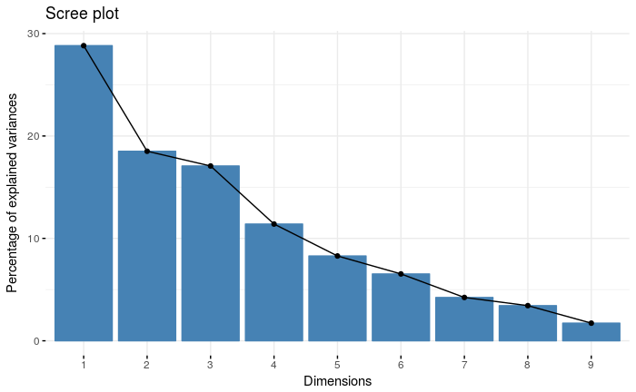

```r
fviz_screeplot(res.ca)
```

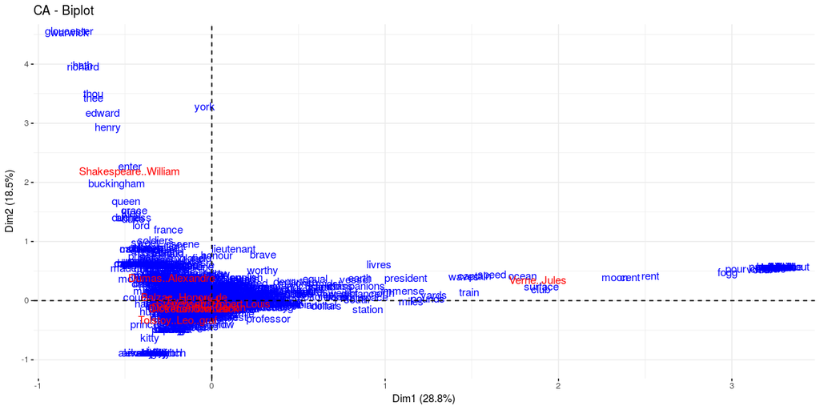

```r
fviz_ca_biplot(res.ca, geom="text")
```

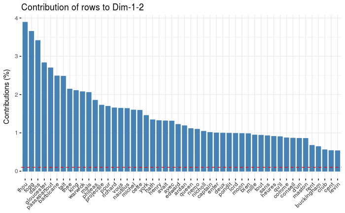

```r
fviz_contrib(res.ca, choice = "row", axes = 1:2, top = 50)
```

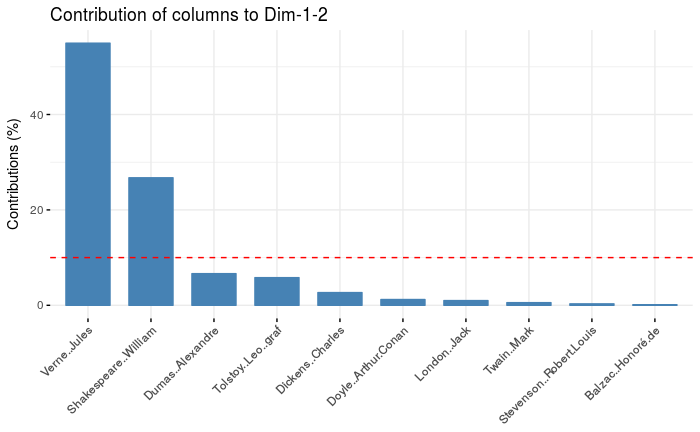

```r
fviz_contrib(res.ca, choice = "col", axes = 1:2, top = 50)
```

```r
proportion <-  bind_rows(texts) %>%
  mutate(
    word = str_extract(word, "[a-z']+"),
    word = gsub('[[:digit:]]+', '', word)) %>%
  filter(!is.na(word), word != "") %>%
  filter(nchar(word) > 3) %>%
  count(author, word) %>%
  group_by(author) %>%
  mutate(proportion = n / sum(n)) %>%
  select(-n) %>%
  spread(author, proportion) %>%
  gather(author, proportion, -word, -`Dumas, Alexandre`)
```

$t = r \sqrt{\frac{n - 2}{1 - r^2}}$

with Student-t distribution df = n − 2

```r
cor.test(data = proportion[proportion$author =="Balzac, Honoré de",],
         ~ proportion + `Dumas, Alexandre`)
```

```
    Pearson's product-moment correlation

data:  proportion and Dumas, Alexandre
t = 59.686, df = 6995, p-value < 2.2e-16
alternative hypothesis: true correlation is not equal to 0
95 percent confidence interval:
 0.5651533 0.5962092
sample estimates:
      cor
0.5808926
```

```r
cor.test(data = proportion[proportion$author =="Shakespeare, William",],
         ~ proportion + `Dumas, Alexandre`)
```

```
    Pearson's product-moment correlation

data:  proportion and Dumas, Alexandre
t = 33.858, df = 5468, p-value < 2.2e-16
alternative hypothesis: true correlation is not equal to 0
95 percent confidence interval:
 0.3941545 0.4379769
sample estimates:
      cor
0.4163074
```

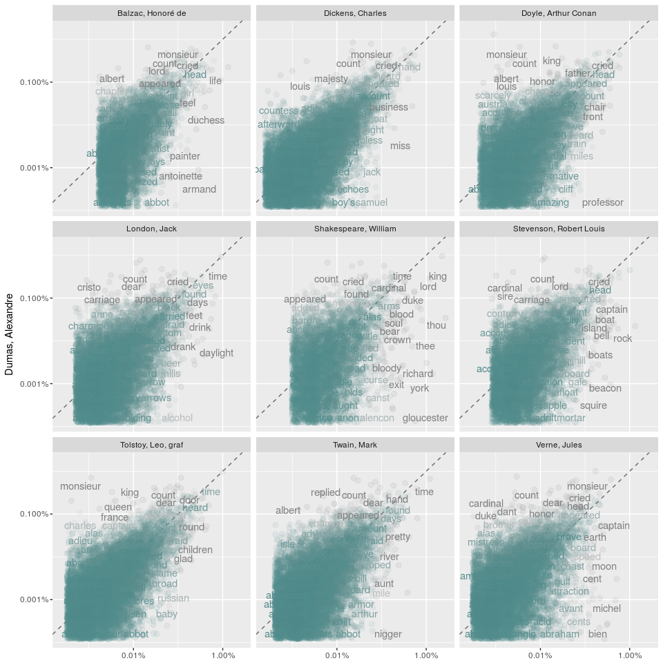

```r
ggplot(proportion, aes(x = proportion, y = `Dumas, Alexandre`,
                       color = abs(`Dumas, Alexandre` - proportion))) +
  geom_abline(color = "gray40", lty = 2) +
  geom_jitter(alpha = 0.1, size = 2.5, width = 0.3, height = 0.3) +
  geom_text(aes(label = word), check_overlap = TRUE, vjust = 1.5) +
  scale_x_log10(labels = percent_format()) +
  scale_y_log10(labels = percent_format()) +
  scale_color_gradient(limits = c(0, 0.001), low = "darkslategray4", high = "gray75") +
  facet_wrap(~author, ncol = 3) +
  theme(legend.position="none") +
  labs(y = "Dumas, Alexandre", x = NULL)
```

# Latent Dirichlet Allocation (LDA)

Here we will show how LDA works using a few books from some chosen authors:

```r
titles <- c("Pride and Prejudice", "Crime and Punishment",
            "Adventures of Huckleberry Finn", "Wuthering Heights")
(books_info <- gutenberg_works(title %in% titles))
```

| gutenberg_id | title | author | gutenberg_author_id | language | gutenberg_bookshelf | rights | has_text |
| --- | --- | --- | --- | --- | --- | --- | --- |
| 76 | Adventures of Huckleberry Finn | Twain, Mark | 53 | en | Best Books Ever Listings/Banned Books from Anne Haight's list | Public domain in the USA. | TRUE |
| 768 | Wuthering Heights | Brontë, Emily | 405 | en | Gothic Fiction/Movie Books/Best Books Ever Listings | Public domain in the USA. | TRUE |
| 1342 | Pride and Prejudice | Austen, Jane | 68 | en | Best Books Ever Listings/Harvard Classics | Public domain in the USA. | TRUE |
| 2554 | Crime and Punishment | Dostoyevsky, Fyodor | 314 | en | Best Books Ever Listings/Crime Fiction/Harvard Classics | Public domain in the USA. | TRUE |

Download books’ texts:

```r
books <- books_info %>%
  gutenberg_download(meta_fields = "title")
table(books$title)
```

```
Adventures of Huckleberry Finn           Crime and Punishment            Pride and Prejudice              Wuthering Heights
                         11980                          22061                          13030                          12085
```

```r
# divide into documents, each representing one chapter
by_chapter <- books %>%
  group_by(title) %>%
  mutate(chapter = cumsum(str_detect(text, regex("^chapter ", ignore_case = TRUE)))) %>%
  ungroup() %>%
  filter(chapter > 0) %>%
  unite(document, title, chapter)
head(by_chapter)
```

| gutenberg_id | text | document |
| --- | --- | --- |
| 76 | CHAPTER I. Civilizing Huck.--Miss Watson.--Tom Sawyer Waits. | Adventures of Huckleberry Finn_1 |
| 76 |  | Adventures of Huckleberry Finn_1 |
| 76 | CHAPTER II. The Boys Escape Jim.--Torn Sawyer's Gang.--Deep-laid Plans. | Adventures of Huckleberry Finn_2 |
| 76 |  | Adventures of Huckleberry Finn_2 |
| 76 | CHAPTER III. A Good Going-over.--Grace Triumphant.--"One of Tom Sawyers's | Adventures of Huckleberry Finn_3 |
| 76 | Lies". | Adventures of Huckleberry Finn_3 |

```r
# split into words
by_chapter_word <- by_chapter %>%
  unnest_tokens(word, text)
head(by_chapter_word)
```

| gutenberg_id | document | word |
| --- | --- | --- |
| 76 | Adventures of Huckleberry Finn_1 | chapter |
| 76 | Adventures of Huckleberry Finn_1 | i |
| 76 | Adventures of Huckleberry Finn_1 | civilizing |
| 76 | Adventures of Huckleberry Finn_1 | huck |
| 76 | Adventures of Huckleberry Finn_1 | miss |
| 76 | Adventures of Huckleberry Finn_1 | watson |

```r
# find document-word counts
word_counts <- by_chapter_word %>%
  anti_join(stop_words) %>%
  filter(nchar(word) > 2) %>%
  count(document, word, sort = TRUE) %>%
  ungroup()
head(word_counts)
```

| document | word | n |
| --- | --- | --- |
| Crime and Punishment_30 | sonia | 92 |
| Crime and Punishment_28 | ivanovna | 88 |
| Crime and Punishment_28 | katerina | 68 |
| Crime and Punishment_13 | raskolnikov | 59 |
| Crime and Punishment_24 | sonia | 54 |
| Crime and Punishment_25 | porfiry | 52 |

`topicmodels` package includes an easy to use LDA implementation.

```r
library(topicmodels)
```

First, we need to convert the above long data.frame `word_counts` into a documents vs terms table with word frequencies:

```r
chapters_dtm <- word_counts %>%
  cast_dtm(document, word, n)
chapters_dtm
```

```
<<DocumentTermMatrix (documents: 220, terms: 17666)>>
Non-/sparse entries: 111108/3775412
Sparsity           : 97%
Maximal term length: 21
Weighting          : term frequency (tf)
```

```r
chapters_lda <- LDA(chapters_dtm, k = 4, control = list(seed = 1234))
chapters_lda
```

```
A LDA_VEM topic model with 4 topics.
```

To access the estimated model parameters we can call `tidy()` function. Below, we print probabilities of words in different topics, $\boldsymbol \beta$.

```r
chapter_topics <- tidy(chapters_lda, matrix = "beta")
chapter_topics
```

| topic | term | beta |
| --- | --- | --- |
| 1 | sonia | 6.045310e-03 |
| 2 | sonia | 1.894557e-19 |
| 3 | sonia | 8.913936e-20 |
| 4 | sonia | 5.813961e-94 |
| 1 | ivanovna | 4.395104e-03 |
| 2 | ivanovna | 1.648269e-15 |
| 3 | ivanovna | 9.206067e-13 |
| 4 | ivanovna | 2.134217e-98 |
| 1 | katerina | 3.529154e-03 |
| 2 | katerina | 5.870691e-15 |

[output cut: 990 more lines]

We can print top 5 words for each topic:

```r
top_terms <- chapter_topics %>%
  group_by(topic) %>%
  top_n(5, beta) %>%
  ungroup() %>%
  arrange(topic, -beta)
top_terms
```

| topic | term | beta |
| --- | --- | --- |
| 1 | raskolnikov | 0.011845540 |
| 1 | time | 0.006225955 |
| 1 | sonia | 0.006045310 |
| 1 | razumihin | 0.005293731 |
| 1 | dounia | 0.004934280 |
| 2 | elizabeth | 0.015879718 |
| 2 | darcy | 0.009921499 |
| 2 | bennet | 0.007820163 |
| 2 | miss | 0.007527572 |
| 2 | jane | 0.006995588 |

[output cut: 10 more lines]

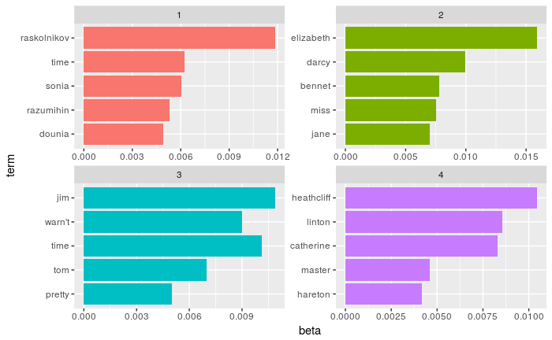

```r
top_terms %>%
  mutate(term = reorder(term, beta)) %>%
  ggplot(aes(term, beta, fill = factor(topic))) +
  geom_col(show.legend = FALSE) +
  facet_wrap(~ topic, scales = "free") +
  coord_flip()
```

We can also look at the probabilities of chapters in different topics:

```r
chapters_gamma <- tidy(chapters_lda, matrix = "gamma")
chapters_gamma
```

| document | topic | gamma |
| --- | --- | --- |
| Crime and Punishment_30 | 1 | 9.999659e-01 |
| Crime and Punishment_28 | 1 | 9.823907e-01 |
| Crime and Punishment_13 | 1 | 9.999752e-01 |
| Crime and Punishment_24 | 1 | 9.999680e-01 |
| Crime and Punishment_25 | 1 | 9.999717e-01 |
| Crime and Punishment_27 | 1 | 9.999691e-01 |
| Crime and Punishment_19 | 1 | 9.999721e-01 |
| Crime and Punishment_3 | 1 | 9.133752e-01 |
| Crime and Punishment_39 | 1 | 9.999812e-01 |
| Crime and Punishment_14 | 1 | 9.989902e-01 |

[output cut: 870 more lines]

We can check who well did LDA infer the chapter’s membership

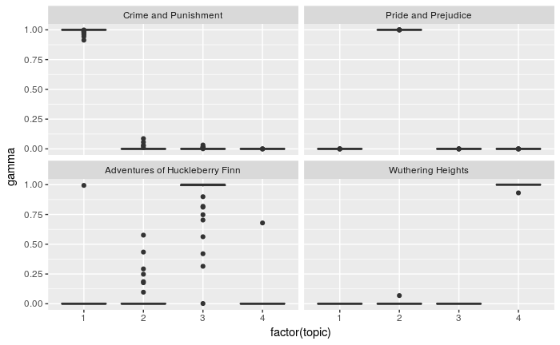

```r
chapters_gamma <- chapters_gamma %>%
  separate(document, c("title", "chapter"), sep = "_", convert = TRUE)
chapters_gamma %>%
  mutate(title = reorder(title, gamma * topic)) %>%
  ggplot(aes(factor(topic), gamma)) +
  geom_boxplot() +
  facet_wrap(~ title)
```

```r
chapter_classifications <- chapters_gamma %>%
  group_by(title, chapter) %>%
  top_n(1, gamma) %>%
  ungroup()
chapter_classifications
```

| title | chapter | topic | gamma |
| --- | --- | --- | --- |
| Crime and Punishment | 30 | 1 | 0.9999659 |
| Crime and Punishment | 28 | 1 | 0.9823907 |
| Crime and Punishment | 13 | 1 | 0.9999752 |
| Crime and Punishment | 24 | 1 | 0.9999680 |
| Crime and Punishment | 25 | 1 | 0.9999717 |
| Crime and Punishment | 27 | 1 | 0.9999691 |
| Crime and Punishment | 19 | 1 | 0.9999721 |
| Crime and Punishment | 3 | 1 | 0.9133752 |
| Crime and Punishment | 39 | 1 | 0.9999812 |
| Crime and Punishment | 14 | 1 | 0.9989902 |

[output cut: 210 more lines]

```r
book_topics <- chapter_classifications %>%
  count(title, topic) %>%
  group_by(title) %>%
  top_n(1, n) %>%
  ungroup() %>%
  transmute(consensus = title, topic)
chapter_classifications %>%
  inner_join(book_topics, by = "topic") %>%
  filter(title != consensus)
```

| title | chapter | topic | gamma | consensus |
| --- | --- | --- | --- | --- |
| Adventures of Huckleberry Finn | 38 | 1 | 0.9941500 | Crime and Punishment |
| Adventures of Huckleberry Finn | 31 | 2 | 0.5763534 | Pride and Prejudice |
| Adventures of Huckleberry Finn | 5 | 4 | 0.6787634 | Wuthering Heights |